# Model Building Homework

```r
library(tidyverse)
library(janitor)
library(modelr)
library(GGally)
library(ggfortify)
library(here)
library(lubridate)
```

```r
avocado <- read_csv(here('data/avocado.csv')) %>%
  clean_names()

names(avocado)
dim(avocado)
head(avocado)
```

[output not shown]

```r
# clean up data
# create `month` column from `date` and make it a `factor`
# make `type` a `factor`
# rename plu columns to make more sense
# remove un-needed columns

avocado_clean <- avocado %>%
  mutate(month = as.factor(month(date)),
         type = as.factor(type)) %>%
  rename(total_plu_4046 = x4046,
         total_plu_4225 = x4225,
         total_plu_4770 = x4770) %>%
  select(-c(x1, date))

avocado_clean
```

| average_price | total_volume | total_plu_4046 | total_plu_4225 | total_plu_4770 | total_bags | small_bags | large_bags | x_large_bags | type | year | region | month |
| --- | --- | --- | --- | --- | --- | --- | --- | --- | --- | --- | --- | --- |
| 1.33 | 64236.62 | 1036.74 | 54454.85 | 48.16 | 8696.87 | 8603.62 | 93.25 | 0.00 | conventional | 2015 | Albany | 12 |
| 1.35 | 54876.98 | 674.28 | 44638.81 | 58.33 | 9505.56 | 9408.07 | 97.49 | 0.00 | conventional | 2015 | Albany | 12 |
| 0.93 | 118220.22 | 794.70 | 109149.67 | 130.50 | 8145.35 | 8042.21 | 103.14 | 0.00 | conventional | 2015 | Albany | 12 |
| 1.08 | 78992.15 | 1132.00 | 71976.41 | 72.58 | 5811.16 | 5677.40 | 133.76 | 0.00 | conventional | 2015 | Albany | 12 |
| 1.28 | 51039.60 | 941.48 | 43838.39 | 75.78 | 6183.95 | 5986.26 | 197.69 | 0.00 | conventional | 2015 | Albany | 11 |
| 1.26 | 55979.78 | 1184.27 | 48067.99 | 43.61 | 6683.91 | 6556.47 | 127.44 | 0.00 | conventional | 2015 | Albany | 11 |
| 0.99 | 83453.76 | 1368.92 | 73672.72 | 93.26 | 8318.86 | 8196.81 | 122.05 | 0.00 | conventional | 2015 | Albany | 11 |
| 0.98 | 109428.33 | 703.75 | 101815.36 | 80.00 | 6829.22 | 6266.85 | 562.37 | 0.00 | conventional | 2015 | Albany | 11 |
| 1.02 | 99811.42 | 1022.15 | 87315.57 | 85.34 | 11388.36 | 11104.53 | 283.83 | 0.00 | conventional | 2015 | Albany | 11 |
| 1.07 | 74338.76 | 842.40 | 64757.44 | 113.00 | 8625.92 | 8061.47 | 564.45 | 0.00 | conventional | 2015 | Albany | 10 |

[output cut: 990 more lines]

```r
avocado_trim <- avocado_clean %>%
  select(-region)
```

```r
# check for any aliased variables
alias(average_price ~ ., data = avocado_clean)
```

```
Model :
average_price ~ total_volume + total_plu_4046 + total_plu_4225 +
    total_plu_4770 + total_bags + small_bags + large_bags + x_large_bags +
    type + year + region + month
```

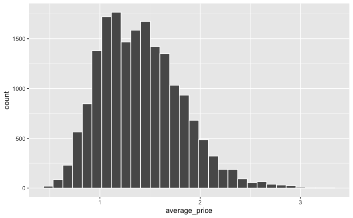

```r
# plot `average_price` to see how it looks
ggplot(avocado_clean, aes(average_price)) +
  geom_histogram(colour = "white")
```

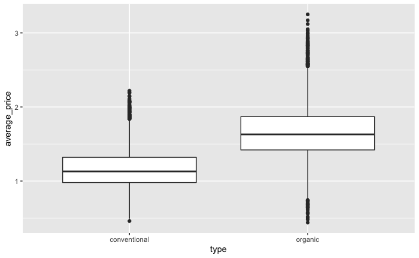

```r
ggplot(avocado_clean, aes(x = type, y = average_price)) +
  geom_boxplot()
```

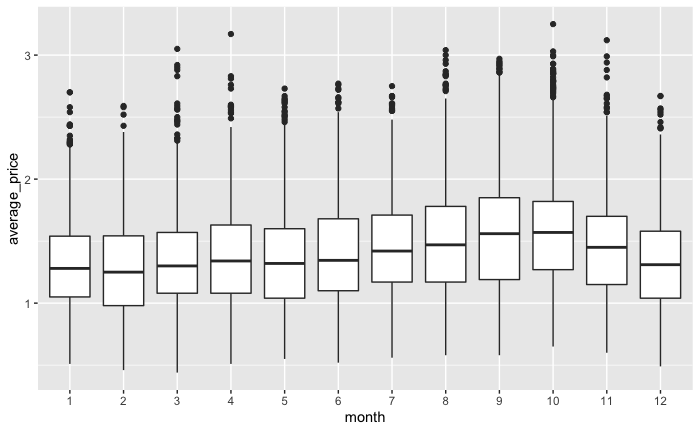

```r
ggplot(avocado_clean, aes(x = month, y = average_price)) +
  geom_boxplot()
```

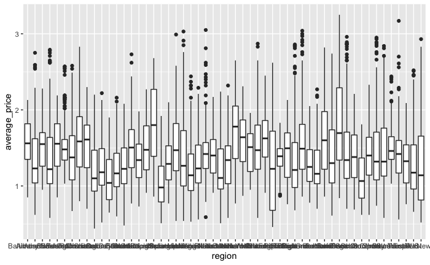

```r
ggplot(avocado_clean, aes(x = region, y = average_price)) +
  geom_boxplot()
```

- The `average_price` data looks to be pretty normally distributed.
- The `type` boxplot show a clear difference between the two types so this could be a good predictor to use.
- The `month` boxplot show variance throughout the year which could also affect price.
- The `region` boxplot show variance throughout regions which could also affect price.

[output not shown]

[output cut: 109 more lines]

[output not shown]

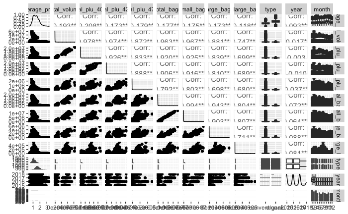

```r
# run `ggpairs()` and look for interesting variables
# region is causing problems so remove it for the moment
avocado_clean %>%
  select(-region) %>%
  ggpairs()
```

### Interesting predictors

average_price ~ type, month,

```r
# create first model
mod1a <- lm(average_price ~ type, data = avocado_clean)
summary(mod1a)
```

```
Call:
lm(formula = average_price ~ type, data = avocado_clean)

Residuals:
     Min       1Q   Median       3Q      Max
-1.21400 -0.20400 -0.02804  0.18600  1.59600

Coefficients:
            Estimate Std. Error t value Pr(>|t|)
(Intercept) 1.158040   0.003321   348.7   <2e-16 ***
typeorganic 0.495959   0.004697   105.6   <2e-16 ***
---
Signif. codes:  0 ‘***’ 0.001 ‘**’ 0.01 ‘*’ 0.05 ‘.’ 0.1 ‘ ’ 1

Residual standard error: 0.3173 on 18247 degrees of freedom
Multiple R-squared:  0.3793,    Adjusted R-squared:  0.3792
F-statistic: 1.115e+04 on 1 and 18247 DF,  p-value: < 2.2e-16
```

`average_price ~ type` looks to be a good starting point for the model: Adjusted R-squared: 0.3792

```r
# create second model
mod1b <- lm(average_price ~ month, data = avocado_clean)
summary(mod1b)
```

```
Call:
lm(formula = average_price ~ month, data = avocado_clean)

Residuals:
     Min       1Q   Median       3Q      Max
-0.99265 -0.29660 -0.03208  0.25032  1.79562

Coefficients:
             Estimate Std. Error t value Pr(>|t|)
(Intercept)  1.311019   0.008857 148.022  < 2e-16 ***
month2      -0.036632   0.012911  -2.837  0.00456 **
month3       0.021236   0.012708   1.671  0.09473 .
month4       0.063362   0.013677   4.633 3.63e-06 ***
month5       0.035582   0.013390   2.657  0.00788 **
month6       0.097946   0.014010   6.991 2.83e-12 ***
month7       0.151058   0.013390  11.281  < 2e-16 ***
month8       0.201496   0.013677  14.732  < 2e-16 ***
month9       0.261636   0.014004  18.683  < 2e-16 ***
month10      0.268664   0.013390  20.064  < 2e-16 ***
month11      0.144544   0.013677  10.568  < 2e-16 ***
month12      0.020093   0.013680   1.469  0.14190
---
Signif. codes:  0 ‘***’ 0.001 ‘**’ 0.01 ‘*’ 0.05 ‘.’ 0.1 ‘ ’ 1

Residual standard error: 0.3905 on 18237 degrees of freedom
Multiple R-squared:  0.06009,   Adjusted R-squared:  0.05953
F-statistic:   106 on 11 and 18237 DF,  p-value: < 2.2e-16
```

`month` does look to affect the price but is not as good a starting point so will save to use as an added predictor to the model: Adjusted R-squared: 0.05953

```r
# create third model
mod1c <- lm(average_price ~ region, data = avocado_clean)
summary(mod1c)
```

```
Call:
lm(formula = average_price ~ region, data = avocado_clean)

Residuals:
     Min       1Q   Median       3Q      Max
-0.97095 -0.28423 -0.03432  0.25207  1.76115

Coefficients:
                           Estimate Std. Error t value Pr(>|t|)
(Intercept)                1.561036   0.020006  78.029  < 2e-16 ***
regionAtlanta             -0.223077   0.028293  -7.885 3.33e-15 ***
regionBaltimoreWashington -0.026805   0.028293  -0.947  0.34344
regionBoise               -0.212899   0.028293  -7.525 5.52e-14 ***
regionBoston              -0.030148   0.028293  -1.066  0.28663
regionBuffaloRochester    -0.044201   0.028293  -1.562  0.11824
regionCalifornia          -0.165710   0.028293  -5.857 4.79e-09 ***
regionCharlotte            0.045000   0.028293   1.591  0.11173
regionChicago             -0.004260   0.028293  -0.151  0.88031
regionCincinnatiDayton    -0.351834   0.028293 -12.436  < 2e-16 ***
regionColumbus            -0.308254   0.028293 -10.895  < 2e-16 ***
regionDallasFtWorth       -0.475444   0.028293 -16.805  < 2e-16 ***
regionDenver              -0.342456   0.028293 -12.104  < 2e-16 ***
regionDetroit             -0.284941   0.028293 -10.071  < 2e-16 ***
regionGrandRapids         -0.056036   0.028293  -1.981  0.04765 *
regionGreatLakes          -0.222485   0.028293  -7.864 3.94e-15 ***
regionHarrisburgScranton  -0.047751   0.028293  -1.688  0.09147 .
regionHartfordSpringfield  0.257604   0.028293   9.105  < 2e-16 ***
regionHouston             -0.513107   0.028293 -18.136  < 2e-16 ***
regionIndianapolis        -0.247041   0.028293  -8.732  < 2e-16 ***
regionJacksonville        -0.050089   0.028293  -1.770  0.07668 .
regionLasVegas            -0.180118   0.028293  -6.366 1.98e-10 ***
regionLosAngeles          -0.345030   0.028293 -12.195  < 2e-16 ***
regionLouisville          -0.274349   0.028293  -9.697  < 2e-16 ***
regionMiamiFtLauderdale   -0.132544   0.028293  -4.685 2.82e-06 ***
regionMidsouth            -0.156272   0.028293  -5.523 3.37e-08 ***
regionNashville           -0.348935   0.028293 -12.333  < 2e-16 ***
regionNewOrleansMobile    -0.256243   0.028293  -9.057  < 2e-16 ***
regionNewYork              0.166538   0.028293   5.886 4.02e-09 ***
regionNortheast            0.040888   0.028293   1.445  0.14843
regionNorthernNewEngland  -0.083639   0.028293  -2.956  0.00312 **
```

[output cut: 14 more lines]

```
regionSouthCentral        -0.459793   0.028293 -16.251  < 2e-16 ***
regionSoutheast           -0.163018   0.028293  -5.762 8.45e-09 ***
regionSpokane             -0.115444   0.028293  -4.080 4.52e-05 ***
regionStLouis             -0.130414   0.028293  -4.609 4.06e-06 ***
regionSyracuse            -0.040710   0.028293  -1.439  0.15020
regionTampa               -0.152189   0.028293  -5.379 7.58e-08 ***
regionTotalUS             -0.242012   0.028293  -8.554  < 2e-16 ***
regionWest                -0.288817   0.028293 -10.208  < 2e-16 ***
regionWestTexNewMexico    -0.299334   0.028356 -10.556  < 2e-16 ***
---
Signif. codes:  0 ‘***’ 0.001 ‘**’ 0.01 ‘*’ 0.05 ‘.’ 0.1 ‘ ’ 1

Residual standard error: 0.3678 on 18195 degrees of freedom
Multiple R-squared:  0.1681,    Adjusted R-squared:  0.1657
F-statistic: 69.38 on 53 and 18195 DF,  p-value: < 2.2e-16
```

`region` has more of an effect that `month` so will save to use as an added predictor too. Adjusted R-squared: 0.1657

```r
anova(mod1b, mod1c)
```

```
Analysis of Variance Table

Model 1: average_price ~ month
Model 2: average_price ~ region
  Res.Df    RSS Df Sum of Sq      F    Pr(>F)
1  18237 2781.1
2  18195 2461.4 42    319.66 56.261 < 2.2e-16 ***
---
Signif. codes:  0 ‘***’ 0.001 ‘**’ 0.01 ‘*’ 0.05 ‘.’ 0.1 ‘ ’ 1
```

```r
null_model <- lm(average_price ~ 1, data = avocado_clean)
anova(null_model, mod1c)
```

```
Analysis of Variance Table

Model 1: average_price ~ 1
Model 2: average_price ~ region
  Res.Df    RSS Df Sum of Sq      F    Pr(>F)
1  18248 2958.9
2  18195 2461.4 53    497.47 69.384 < 2.2e-16 ***
---
Signif. codes:  0 ‘***’ 0.001 ‘**’ 0.01 ‘*’ 0.05 ‘.’ 0.1 ‘ ’ 1
```

Using `anova` Model 2: average_price ~ region seems to be more significant

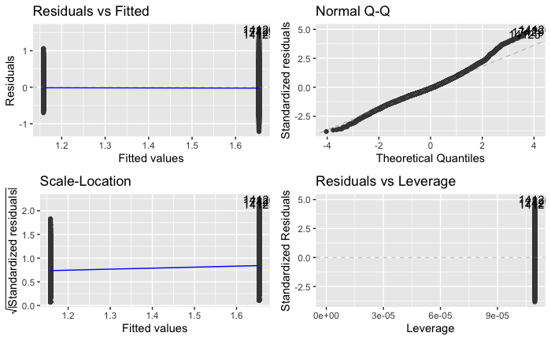

Plotting mod1a to have a look at residuals. Charts look okay.

[output not shown]

[output cut: 76 more lines]

[output not shown]

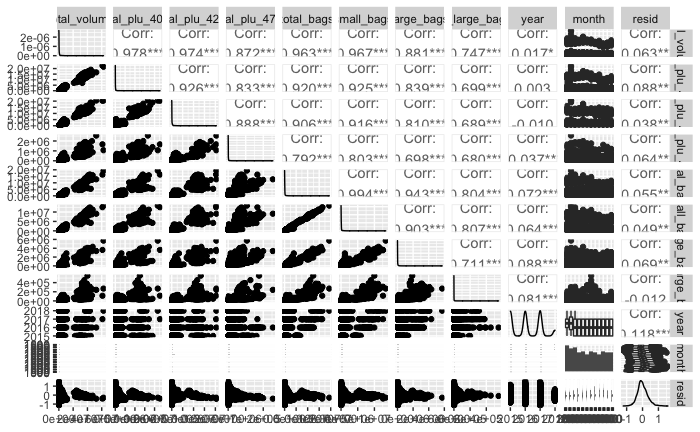

```r
# adding residuals
avo_resid <- avocado_clean %>%
  add_residuals(mod1a) %>%
  select(-c("average_price", "type"))

avo_resid %>%
  select(-region) %>%
  ggpairs()
```

```r
# adding region to first model
mod2a <- lm(average_price ~ type + region, data = avocado_clean)
summary(mod2a)
```

```
Call:
lm(formula = average_price ~ type + region, data = avocado_clean)

Residuals:
     Min       1Q   Median       3Q      Max
-1.09858 -0.16716 -0.01814  0.14692  1.51320

Coefficients:
                           Estimate Std. Error t value Pr(>|t|)
(Intercept)                1.313079   0.014894  88.159  < 2e-16 ***
typeorganic                0.495912   0.004017 123.452  < 2e-16 ***
regionAtlanta             -0.223077   0.020871 -10.688  < 2e-16 ***
regionBaltimoreWashington -0.026805   0.020871  -1.284  0.19906
regionBoise               -0.212899   0.020871 -10.201  < 2e-16 ***
regionBoston              -0.030148   0.020871  -1.444  0.14863
regionBuffaloRochester    -0.044201   0.020871  -2.118  0.03421 *
regionCalifornia          -0.165710   0.020871  -7.940 2.15e-15 ***
regionCharlotte            0.045000   0.020871   2.156  0.03109 *
regionChicago             -0.004260   0.020871  -0.204  0.83826
regionCincinnatiDayton    -0.351834   0.020871 -16.857  < 2e-16 ***
regionColumbus            -0.308254   0.020871 -14.769  < 2e-16 ***
regionDallasFtWorth       -0.475444   0.020871 -22.780  < 2e-16 ***
regionDenver              -0.342456   0.020871 -16.408  < 2e-16 ***
regionDetroit             -0.284941   0.020871 -13.652  < 2e-16 ***
regionGrandRapids         -0.056036   0.020871  -2.685  0.00726 **
regionGreatLakes          -0.222485   0.020871 -10.660  < 2e-16 ***
regionHarrisburgScranton  -0.047751   0.020871  -2.288  0.02216 *
regionHartfordSpringfield  0.257604   0.020871  12.342  < 2e-16 ***
regionHouston             -0.513107   0.020871 -24.584  < 2e-16 ***
regionIndianapolis        -0.247041   0.020871 -11.836  < 2e-16 ***
regionJacksonville        -0.050089   0.020871  -2.400  0.01641 *
regionLasVegas            -0.180118   0.020871  -8.630  < 2e-16 ***
regionLosAngeles          -0.345030   0.020871 -16.531  < 2e-16 ***
regionLouisville          -0.274349   0.020871 -13.145  < 2e-16 ***
regionMiamiFtLauderdale   -0.132544   0.020871  -6.351 2.20e-10 ***
regionMidsouth            -0.156272   0.020871  -7.487 7.35e-14 ***
regionNashville           -0.348935   0.020871 -16.718  < 2e-16 ***
regionNewOrleansMobile    -0.256243   0.020871 -12.277  < 2e-16 ***
regionNewYork              0.166538   0.020871   7.979 1.56e-15 ***
regionNortheast            0.040888   0.020871   1.959  0.05013 .
```

[output cut: 15 more lines]

```
regionSouthCentral        -0.459793   0.020871 -22.030  < 2e-16 ***
regionSoutheast           -0.163018   0.020871  -7.811 6.00e-15 ***
regionSpokane             -0.115444   0.020871  -5.531 3.22e-08 ***
regionStLouis             -0.130414   0.020871  -6.248 4.24e-10 ***
regionSyracuse            -0.040710   0.020871  -1.951  0.05113 .
regionTampa               -0.152189   0.020871  -7.292 3.18e-13 ***
regionTotalUS             -0.242012   0.020871 -11.595  < 2e-16 ***
regionWest                -0.288817   0.020871 -13.838  < 2e-16 ***
regionWestTexNewMexico    -0.297114   0.020918 -14.204  < 2e-16 ***
---
Signif. codes:  0 ‘***’ 0.001 ‘**’ 0.01 ‘*’ 0.05 ‘.’ 0.1 ‘ ’ 1

Residual standard error: 0.2713 on 18194 degrees of freedom
Multiple R-squared:  0.5473,    Adjusted R-squared:  0.546
F-statistic: 407.4 on 54 and 18194 DF,  p-value: < 2.2e-16
```

Adding in `region` predictor has a decent impact, Adjusted R-squared: 0.546, up from 0.3792. No much of a penalty between r values yet either.

```r
# adding month as another predictor
mod2b <- lm(average_price ~ type + region + month, data = avocado_clean)
summary(mod2b)
```

```
Call:
lm(formula = average_price ~ type + region + month, data = avocado_clean)

Residuals:
     Min       1Q   Median       3Q      Max
-1.06696 -0.15364 -0.00658  0.14490  1.54481

Coefficients:
                           Estimate Std. Error t value Pr(>|t|)
(Intercept)                1.218110   0.014895  81.777  < 2e-16 ***
typeorganic                0.495905   0.003742 132.521  < 2e-16 ***
regionAtlanta             -0.223077   0.019443 -11.474  < 2e-16 ***
regionBaltimoreWashington -0.026805   0.019443  -1.379 0.168020
regionBoise               -0.212899   0.019443 -10.950  < 2e-16 ***
regionBoston              -0.030148   0.019443  -1.551 0.121015
regionBuffaloRochester    -0.044201   0.019443  -2.273 0.023014 *
regionCalifornia          -0.165710   0.019443  -8.523  < 2e-16 ***
regionCharlotte            0.045000   0.019443   2.314 0.020652 *
regionChicago             -0.004260   0.019443  -0.219 0.826557
regionCincinnatiDayton    -0.351834   0.019443 -18.096  < 2e-16 ***
regionColumbus            -0.308254   0.019443 -15.854  < 2e-16 ***
regionDallasFtWorth       -0.475444   0.019443 -24.454  < 2e-16 ***
regionDenver              -0.342456   0.019443 -17.614  < 2e-16 ***
regionDetroit             -0.284941   0.019443 -14.655  < 2e-16 ***
regionGrandRapids         -0.056036   0.019443  -2.882 0.003955 **
regionGreatLakes          -0.222485   0.019443 -11.443  < 2e-16 ***
regionHarrisburgScranton  -0.047751   0.019443  -2.456 0.014058 *
regionHartfordSpringfield  0.257604   0.019443  13.249  < 2e-16 ***
regionHouston             -0.513107   0.019443 -26.391  < 2e-16 ***
regionIndianapolis        -0.247041   0.019443 -12.706  < 2e-16 ***
regionJacksonville        -0.050089   0.019443  -2.576 0.009997 **
regionLasVegas            -0.180118   0.019443  -9.264  < 2e-16 ***
regionLosAngeles          -0.345030   0.019443 -17.746  < 2e-16 ***
regionLouisville          -0.274349   0.019443 -14.111  < 2e-16 ***
regionMiamiFtLauderdale   -0.132544   0.019443  -6.817 9.58e-12 ***
regionMidsouth            -0.156272   0.019443  -8.038 9.72e-16 ***
regionNashville           -0.348935   0.019443 -17.947  < 2e-16 ***
regionNewOrleansMobile    -0.256243   0.019443 -13.179  < 2e-16 ***
regionNewYork              0.166538   0.019443   8.566  < 2e-16 ***
regionNortheast            0.040888   0.019443   2.103 0.035482 *
```

[output cut: 26 more lines]

```
month4                     0.063362   0.008852   7.158 8.53e-13 ***
month5                     0.035582   0.008667   4.106 4.05e-05 ***
month6                     0.098109   0.009068  10.819  < 2e-16 ***
month7                     0.151058   0.008667  17.429  < 2e-16 ***
month8                     0.201496   0.008852  22.762  < 2e-16 ***
month9                     0.261636   0.009064  28.865  < 2e-16 ***
month10                    0.268664   0.008667  30.999  < 2e-16 ***
month11                    0.144544   0.008852  16.328  < 2e-16 ***
month12                    0.020169   0.008854   2.278 0.022747 *
---
Signif. codes:  0 ‘***’ 0.001 ‘**’ 0.01 ‘*’ 0.05 ‘.’ 0.1 ‘ ’ 1

Residual standard error: 0.2528 on 18183 degrees of freedom
Multiple R-squared:  0.6074,    Adjusted R-squared:  0.606
F-statistic: 432.8 on 65 and 18183 DF,  p-value: < 2.2e-16
```

Adding in `month` has a further good impact: Multiple R-squared: 0.6074, Adjusted R-squared: 0.606, still not being penalised much for the addition.

```r
# add interaction
mod3a <- lm(average_price ~ type + region + month + type:region, data = avocado_clean)
summary(mod3a)
```

```
Call:
lm(formula = average_price ~ type + region + month + type:region,
    data = avocado_clean)

Residuals:
     Min       1Q   Median       3Q      Max
-1.06386 -0.14344 -0.00634  0.13492  1.58555

Coefficients:
                                       Estimate Std. Error t value Pr(>|t|)
(Intercept)                            1.253755   0.019161  65.433  < 2e-16 ***
typeorganic                            0.424556   0.026103  16.265  < 2e-16 ***
regionAtlanta                         -0.279941   0.026103 -10.725  < 2e-16 ***
regionBaltimoreWashington             -0.004556   0.026103  -0.175 0.861436
regionBoise                           -0.272722   0.026103 -10.448  < 2e-16 ***
regionBoston                          -0.044379   0.026103  -1.700 0.089118 .
regionBuffaloRochester                 0.033550   0.026103   1.285 0.198697
regionCalifornia                      -0.243314   0.026103  -9.321  < 2e-16 ***
regionCharlotte                       -0.073669   0.026103  -2.822 0.004774 **
regionChicago                          0.020592   0.026103   0.789 0.430197
regionCincinnatiDayton                -0.333254   0.026103 -12.767  < 2e-16 ***
regionColumbus                        -0.282485   0.026103 -10.822  < 2e-16 ***
regionDallasFtWorth                   -0.502308   0.026103 -19.244  < 2e-16 ***
regionDenver                          -0.274793   0.026103 -10.527  < 2e-16 ***
regionDetroit                         -0.224793   0.026103  -8.612  < 2e-16 ***
regionGrandRapids                     -0.023728   0.026103  -0.909 0.363353
regionGreatLakes                      -0.166864   0.026103  -6.393 1.67e-10 ***
regionHarrisburgScranton              -0.089941   0.026103  -3.446 0.000571 ***
regionHartfordSpringfield              0.059290   0.026103   2.271 0.023134 *
regionHouston                         -0.523669   0.026103 -20.062  < 2e-16 ***
regionIndianapolis                    -0.203905   0.026103  -7.812 5.95e-15 ***
regionJacksonville                    -0.155148   0.026103  -5.944 2.84e-09 ***
regionLasVegas                        -0.335799   0.026103 -12.865  < 2e-16 ***
regionLosAngeles                      -0.372308   0.026103 -14.263  < 2e-16 ***
regionLouisville                      -0.243432   0.026103  -9.326  < 2e-16 ***
regionMiamiFtLauderdale               -0.094438   0.026103  -3.618 0.000298 ***
regionMidsouth                        -0.141598   0.026103  -5.425 5.88e-08 ***
regionNashville                       -0.335858   0.026103 -12.867  < 2e-16 ***
regionNewOrleansMobile                -0.263491   0.026103 -10.094  < 2e-16 ***
regionNewYork                          0.053373   0.026103   2.045 0.040897 *
```

[output cut: 80 more lines]

```
typeorganic:regionSouthCentral         0.039112   0.036915   1.060 0.289371
typeorganic:regionSoutheast            0.045444   0.036915   1.231 0.218322
typeorganic:regionSpokane              0.234675   0.036915   6.357 2.10e-10 ***
typeorganic:regionStLouis              0.065207   0.036915   1.766 0.077342 .
typeorganic:regionSyracuse            -0.157751   0.036915  -4.273 1.94e-05 ***
typeorganic:regionTampa               -0.010059   0.036915  -0.272 0.785243
typeorganic:regionTotalUS              0.029467   0.036915   0.798 0.424732
typeorganic:regionWest                 0.149704   0.036915   4.055 5.03e-05 ***
typeorganic:regionWestTexNewMexico     0.421760   0.036998  11.399  < 2e-16 ***
---
Signif. codes:  0 ‘***’ 0.001 ‘**’ 0.01 ‘*’ 0.05 ‘.’ 0.1 ‘ ’ 1

Residual standard error: 0.2399 on 18130 degrees of freedom
Multiple R-squared:  0.6472,    Adjusted R-squared:  0.6449
F-statistic: 281.9 on 118 and 18130 DF,  p-value: < 2.2e-16
```

Adding an interaction between `type:region` gets us further, Multiple R-squared: 0.6472, Adjusted R-squared: 0.6449, penalties still looking lean.

```r
mod3b <- lm(average_price ~ type + region + month + type:month, data = avocado_clean)
summary(mod3b)
```

```
Call:
lm(formula = average_price ~ type + region + month + type:month,
    data = avocado_clean)

Residuals:
     Min       1Q   Median       3Q      Max
-1.05104 -0.15295 -0.00806  0.14450  1.56074

Coefficients:
                           Estimate Std. Error t value Pr(>|t|)
(Intercept)                1.224136   0.015807  77.440  < 2e-16 ***
typeorganic                0.483848   0.011434  42.316  < 2e-16 ***
regionAtlanta             -0.223077   0.019390 -11.505  < 2e-16 ***
regionBaltimoreWashington -0.026805   0.019390  -1.382 0.166867
regionBoise               -0.212899   0.019390 -10.980  < 2e-16 ***
regionBoston              -0.030148   0.019390  -1.555 0.120008
regionBuffaloRochester    -0.044201   0.019390  -2.280 0.022644 *
regionCalifornia          -0.165710   0.019390  -8.546  < 2e-16 ***
regionCharlotte            0.045000   0.019390   2.321 0.020310 *
regionChicago             -0.004260   0.019390  -0.220 0.826093
regionCincinnatiDayton    -0.351834   0.019390 -18.145  < 2e-16 ***
regionColumbus            -0.308254   0.019390 -15.898  < 2e-16 ***
regionDallasFtWorth       -0.475444   0.019390 -24.520  < 2e-16 ***
regionDenver              -0.342456   0.019390 -17.661  < 2e-16 ***
regionDetroit             -0.284941   0.019390 -14.695  < 2e-16 ***
regionGrandRapids         -0.056036   0.019390  -2.890 0.003858 **
regionGreatLakes          -0.222485   0.019390 -11.474  < 2e-16 ***
regionHarrisburgScranton  -0.047751   0.019390  -2.463 0.013800 *
regionHartfordSpringfield  0.257604   0.019390  13.285  < 2e-16 ***
regionHouston             -0.513107   0.019390 -26.462  < 2e-16 ***
regionIndianapolis        -0.247041   0.019390 -12.741  < 2e-16 ***
regionJacksonville        -0.050089   0.019390  -2.583 0.009796 **
regionLasVegas            -0.180118   0.019390  -9.289  < 2e-16 ***
regionLosAngeles          -0.345030   0.019390 -17.794  < 2e-16 ***
regionLouisville          -0.274349   0.019390 -14.149  < 2e-16 ***
regionMiamiFtLauderdale   -0.132544   0.019390  -6.836 8.42e-12 ***
regionMidsouth            -0.156272   0.019390  -8.059 8.14e-16 ***
regionNashville           -0.348935   0.019390 -17.996  < 2e-16 ***
regionNewOrleansMobile    -0.256243   0.019390 -13.215  < 2e-16 ***
regionNewYork              0.166538   0.019390   8.589  < 2e-16 ***
```

[output cut: 38 more lines]

```
typeorganic:month4        -0.019788   0.017657  -1.121 0.262434
typeorganic:month5         0.030200   0.017287   1.747 0.080656 .
typeorganic:month6         0.036050   0.018087   1.993 0.046265 *
typeorganic:month7         0.015332   0.017287   0.887 0.375130
typeorganic:month8         0.070383   0.017657   3.986 6.74e-05 ***
typeorganic:month9         0.071986   0.018079   3.982 6.87e-05 ***
typeorganic:month10       -0.023160   0.017287  -1.340 0.180346
typeorganic:month11        0.015169   0.017657   0.859 0.390286
typeorganic:month12        0.023749   0.017661   1.345 0.178725
---
Signif. codes:  0 ‘***’ 0.001 ‘**’ 0.01 ‘*’ 0.05 ‘.’ 0.1 ‘ ’ 1

Residual standard error: 0.2521 on 18172 degrees of freedom
Multiple R-squared:  0.6098,    Adjusted R-squared:  0.6081
F-statistic: 373.6 on 76 and 18172 DF,  p-value: < 2.2e-16
```

Not a strong a result here, mod3a much stronger.

# Trying automated model builder

Using `leaps` package, disregarding the `region` predictor

```r
library(leaps)
```

```r
regsubsets_forward <- regsubsets(average_price ~ .,
                                 data = avocado_trim,
                                 nvmax = 10,
                                 method = "forward")
```

```r
sum_regsubsets_forward <- summary(regsubsets_forward)
sum_regsubsets_forward
```

[output not shown]

```r
plot(regsubsets_forward, scale = "adjr2")
```

[output not shown]

```r
plot(regsubsets_forward, scale = "bic")
```

[output not shown]

```r
plot(sum_regsubsets_forward$rsq, type = "b")
```

[output not shown]

# tidy models

Having a quick look at the `tidymodels` package.

```r
library(tidymodels)
library(dotwhisker)
```

```r
ggplot(avocado_clean,
       aes(x = month,
           y = average_price,
           group = type,
           col = type)) +
  geom_point() +
  geom_smooth(method = lm, se = FALSE) +
  scale_color_viridis_d(option = "plasma", end = .7) +
  facet_grid(~type)
```

[output not shown]

```r
lm_mod <- linear_reg()

lm_fit <- lm_mod %>%
  fit(average_price ~ type + region + month, data = avocado_clean)

lm_fit
```

[output not shown]

```r
tidy(lm_fit)
```

[output not shown]

```r
tidy(lm_fit) %>%
  dwplot(dot_args = list(size = 2, color = "black"),
         whisker_args = list(color = "black"),
         vline = geom_vline(xintercept = 0, colour = "grey50", linetype = 2))
```

[output not shown]